# historic_data_tidy

2024-03-06

Import our libraries. We also need a custom function for renaming columns that span multiple rows of excel spreadsheets

```r
library("sf")
library("tidyverse")
library("janitor")
library("readxl")
library("ggspatial")

# we have to step back a directory (../)to import the custom function
source('../scripts/functions.R')
```

Import shapefile provded by Adam (`TreatmentSitesMaster.shp`) as well as the site info provided by Laura (`UB Restoration Site Names.xlsx`.

```r
# define file paths
file_sites_poly <- "/Users/airvine/Library/CloudStorage/OneDrive-Personal/Projects/2024-069-ow-wedzin-kwa-restoration/data/historic_site_info/TreatmentSitesMaster/TreatmentSitesMaster.shp"
file_sites_info <- "/Users/airvine/Library/CloudStorage/OneDrive-Personal/Projects/2024-069-ow-wedzin-kwa-restoration/data/historic_site_info/UB Restoration Site Names.xlsx"

# import data
# read in the shapefile
sites_poly <- sf::st_read(
  dsn = file_sites_poly, quiet = TRUE) %>%
  janitor::clean_names() %>%
  # remove the site_name column since it is not populated
  dplyr::select(-site_name)

# to-do - create a small tribble that we can use to cross-reference the names provided vs our new names

# read in the landowner information

# read in the site details in and tidy
sites_info_raw <- readxl::read_excel(
  path = file_sites_info,
  sheet = "Site Names", skip = 6)
```

We will process the column names in `UB Restoration Site Names.xlsx` a little bit to amalgamate mulitple lines of the excel spreadsheet and get ready for joining with the polygon data.

```r
## get the names of the columns ready with the wkb_ function
sites_info_names <- readxl::read_excel(
  path = file_sites_info,
  sheet = "Site Names") %>%
  wkb_col_names() %>%
  # names(s) changed to "name_s" by janitor::clean_names
  stringr::str_replace_all("name_s", "name") %>%
  stringr::str_replace_all("x2024_site_name", "site_name_proposed")
```

Now we will do a bit of tidying to get multiple years of info for same site into one row and convert to a spatial points file.

```r
sites_info <- sites_info_raw %>%
  purrr::set_names(sites_info_names) %>%
  # if we call the site_name "name" it will show up in the menu of google earth for QA.
  mutate(name = site_name_proposed) %>%
  # #we have merged rows in the excel sheet too so we need to fill down to get all the columns populated
  tidyr::fill(everything(), .direction = c("down")) %>%
  # because "description" is a reserved word for kml we will rename it to "site_description"
  dplyr::rename(site_description = description) %>%
  # because we have more than one row for some sites (multiple years work) we will pivot those columns so they are
  # appended to the end of the same row they came from
  group_by(across(-c(work_done_year, work_done_treatment))) %>%
  mutate(row_number = as.character(row_number())) %>%
  pivot_wider(names_from = row_number, values_from = c("work_done_year", "work_done_treatment")) %>%
  # replace N/A with na
  mutate(previous_name_monitoring_report = str_replace_all(previous_name_monitoring_report, "N/A", NA_character_),
  previous_name_site_survey = str_replace_all(previous_name_monitoring_report, "N/A", NA_character_)) %>%
    # dplyr::mutate(across(everything(), ~na_if(., "N/A")))
  #turn into spatial object
  sf::st_as_sf(coords = c( "coordinates_longitude", "coordinates_latitude"), crs = 4326, remove = FALSE)
```

Join the two datasets spatially (closest point get joins to every polygon) but remove all the sites_info column data when the funder is listed as SERNBC or MWMT because those sites were not in the `UB Restoration Site Names.xlsx` file.

```r
# looks like we have site names for sites done by all fndr (funders) other than SERNBC. So -
sites_joined_raw <- sf::st_join(
  sites_poly,
  sites_info,
  join = sf::st_nearest_feature) %>%
  # remove the sites_info data when the sites are SERNbc and MWMT sites
  dplyr::mutate(across(all_of(setdiff(names(sites_info), "geometry")),
                       ~case_when(fndr %in% c("SERNBC", "MWMT") ~ NA,
                                         TRUE ~ .))) %>%
  # make a new description column that combines comments and site_description
  dplyr::mutate(description = paste0(comments, " - ", site_description))
```

View what we have so far.

```r
sites_joined_raw %>%
  fpr::fpr_kable(font = 12)
```

| fid | type | method | comments | trt_year | trt_date | fndr | spc_plntd | hrs_soak | plnt_dnsty | plnt_type | x_stakes | x_fascines | id | area_sq_m | site_name_proposed | coordinates_latitude | coordinates_longitude | length_m | waterbody | current_landowner | site_description | previous_name_data_inventory | previous_name_2021_report | previous_name_monitoring_report | previous_name_site_survey | name | work_done_year_1 | work_done_year_2 | work_done_treatment_1 | … |
| --- | --- | --- | --- | --- | --- | --- | --- | --- | --- | --- | --- | --- | --- | --- | --- | --- | --- | --- | --- | --- | --- | --- | --- | --- | --- | --- | --- | --- | --- | --- |
| 1 | riparian planting | waterjet stinger | Staking density was increased in the northern portion of polygon b/c instability | 2022 | 2022-05-18 | MWMT | willow all species and black cottonwood | 48 | 1 | live stake | – | – | 1 | 854 | – | – | – | – | – | – | – | – | – | – | – | – | – | – | – | … |
| 2 | re-shape and pegboard and riparian planting | handheld postpounder | Sx live stakes - LS = Live Stake; PB = reshape and pegboard | 2021 | 2021-11-03 | HWI | willow all species | 0 | 1 | live stake | – | – | – | 118 | RC3-2021 | 54.51009 | -126.3417 | 15 | Richfield Creek | Groot | Downstream site on Richfield Creek just north of railway | Groot Site 1 Richfield D/S | Groot 1 Richfield (Lower) | – | – | RC3-2021 | 2021 | – | Bank re-shaping, pegboarding, and livestaking | … |
| 3 | riparian planting | waterjet stinger | – | 2022 | 2022-05-20 | MWMT | willow all species and black cottonwood | 4 | 1 | live stake | – | – | 2 | 432 | – | – | – | – | – | – | – | – | – | – | – | – | – | – | – | … |
| 4 | riparian planting | waterjet stinger | – | 2022 | 2022-05-20 | MWMT | willow all species and black cottonwood | 4 | 1 | live stake | – | – | 3 | 417 | – | – | – | – | – | – | – | – | – | – | – | – | – | – | – | … |
| 5 | riparian planting | stinger & post pounder | included toe armouring with willow burrito | 2021 | 2021-11-02 | HWI | willow all species and black cottonwood | 0 | 1 | live stake and rooted cutting | – | – | – | 101 | RC2-2021 | 54.51346 | -126.3385 | 20 | Richfield Creek | Groot | Middle site just north of field cross-fence | Groot Site 2 Richfield Middle | Groot 2 Richfield (Middle) | – | – | RC2-2021 | 2021 | – | Live staking and toe armouring | … |
| 6 | riparian planting | shovel plant or bar plant | rooted willow cuttings were fill planted by shovel | 2021 | 2021-11-05 | HWI | willow all species | – | 1 | rooted cutting | – | – | – | 1641 | RC2-2021 | 54.51346 | -126.3385 | 20 | Richfield Creek | Groot | Middle site just north of field cross-fence | Groot Site 2 Richfield Middle | Groot 2 Richfield (Middle) | – | – | RC2-2021 | 2021 | – | Live staking and toe armouring | … |
| 7 | riparian planting | stinger & post pounder | vertical fascines installed from water edge up (~2.5m long bundles of 10) | 2022 | 2022-11-02 | SERNBC | willow all species | 0 | 1 | live stake | 440 | 27 | 1 | 591 | – | – | – | – | – | – | – | – | – | – | – | – | – | – | – | … |
| 8 | riparian planting | handheld postpounder | fascines placed and partially buried, cobbly ground not suitable for stinger | 2022 | 2022-11-03 | SERNBC | willow all species | 0 | 2 | live stake | 105 | 11 | 2 | 154 | – | – | – | – | – | – | – | – | – | – | – | – | – | – | – | … |
| 9 | riparian planting | shovel plant or bar plant | cobbly ground, bank seep, fascines partially buried | 2022 | 2022-11-03 | SERNBC | willow all species | 0 | – | live stake | 30 | 5 | 3 | 16 | – | – | – | – | – | – | – | – | – | – | – | – | – | – | – | … |
| 10 | riparian planting | shovel plant or bar plant | steep (4m high bank), cobble/gravel, verticle fascines partially buried | 2022 | 2022-11-22 | SERNBC | willow all species | 0 | 2 | live stake | 140 | 17 | 4 | 105 | – | – | – | – | – | – | – | – | – | – | – | – | – | – | – | … |
| 11 | re-shape and pegboard and riparian planting | all methods | no toe protection burrito | 2021 | 2021-10-20 | HWI | willow all species and black cottonwood | 0 | 1 | live stake | – | – | – | 522 | BR2-2021 | 54.50541 | -126.3212 | 90 | Bulkley River | Dickson | Downstream site accessed through main field | Dickson Site 1 Bulkley D/S | Dickson 1 (Lower) | – | – | BR2-2021 | 2021 | – | Re-sloping, pegboarding, live-staking and planting | … |
| 12 | re-shape and pegboard and riparian planting | all methods | willow burrito placed at toe to protect using straw matting | 2021 | 2021-10-20 | HWI | willow all species, black cottonwood & red-osier dogwood | 0 | 1 | live stake and rooted cutting | – | – | – | 606 | BR1-2021 | 54.50465 | -126.3181 | 110 | Bulkley River | Dickson | Upstream site accessed through main field | Dickson Site 2 Bulkley U/S | Dickson 2 (Upper) | – | – | BR1-2021 | 2021 | – | Re-sloping, pegboarding, toe armouring using willow bundle, live staking and planting | … |
| 13 | riparian planting | waterjet stinger | 700 Sx and 50 Pt, difficult gravel layer for stinger at 30-60cm | 2021 | 2021-05-12 | HWI | willow all species and black cottonwood | 48 | 1 | live stake | 750 | – | – | 1593 | BR5-2016 | 54.51613 | -126.4320 | 225 | Bulkley River | Groot | Site accessed through Roger Groot’s property referred to as “Gibbs”, located west of home property near Perow | Groot Site 4 Bulkley D/S | Groot 4 Bulkley (Lower) | 2 | 2 | BR5-2016 | 2016 | 2021 | This site was stabilized using log revetments (LGL) as part of previous work. | … |
| 14 | riparian planting | all methods | no pounder used, conifers planted by shovel, 330 Sx and 60 Pt | 2021 | 2021-05-12 | HWI | willow all species and black cottonwood | 3 | 1 | live stake | 390 | – | – | 420 | BR4-2016 | 54.51464 | -126.4239 | 80 | Bulkley River | Groot | Site accessed through Roger Groot’s property referred to as “Gibbs”, located west of home property near Perow | Groot Site 5 Bulkley Middle | Groot 5 Bulkley (Middle) | 4 | 4 | BR4-2016 | 2016 | 2021 | This site was stabilized using log revetments (LGL) as part of previous work. | … |
| 15 | riparian planting | waterjet stinger | 140 Sx and 10 Pt, numerous conifers planted | 2021 | 2021-05-14 | HWI | willow all species and black cottonwood | 4 | 1 | live stake | 150 | – | – | 446 | BR3-2016 | 54.51893 | -126.4035 | 80 | Bulkley River | Groot | Site accessed through Roger Groot’s property referred to as “Gibbs”, located west of home property near Perow | Groot Site 6 Bulkley U/S | Groot 6 Bulkley (Upper) | 3 | 3 | BR3-2016 | 2016 | 2021 | This site was stabilized using log revetments (LGL) as part of previous work. | … |
| 16 | riparian planting | waterjet stinger | deep staking >2m, LGL strucutures | 2021 | 2021-05-05 | HWI | willow all species and black cottonwood | 0 | 1 | live stake | – | – | – | 661 | MX1-2021 | 54.37900 | -126.1353 | 100 | Maxan Creek | Strimbold | Site is located ~ 2.5km southwest of landowner’s home farm yard and is accessed via rough road that begins in farmyard and heads south | Strimbold Site 2 Maxan D/S | Strimbold Site 2 (Lower) | 1 | 1 | MX1-2021 | 2021 | – | Bank re-shaping, pegboarding, and livestaking | … |
| 17 | re-shape and pegboard and riparian planting | all methods | no toe burrito, significant re-grade | 2021 | 2021-10-12 | HWI | willow all species, black cottonwood & red-osier dogwood | 0 | 1 | live stake and rooted cutting | – | – | – | 451 | MX2-? | 54.36852 | -126.1618 | 80 | Maxan Creek | Strimbold | Site is located ~ 900m southeast from farm house across large hay field | Strimbold Site 1 Maxan U/S | Strimbold Site 1 (Upper) | – | – | MX2-? | ? | 2021 | This site was stabilized using log revetments (LGL) as part of previous work. | … |
| 18 | re-shape and pegboard and riparian planting | all methods | toe protection with willow burrito | 2021 | 2021-10-29 | HWI | willow all species and black cottonwood | 0 | 1 | live stake and rooted cutting | – | – | – | 133 | RC1-2021 | 54.51728 | -126.3378 | 40 | Richfield Creek | Groot | Uppermost site north of Highway 16 | Groot Site 3 Richfield U/S | Groot 3 Richfield (Upper) | – | – | RC1-2021 | 2021 | – | re-slope, pegboarding, live staking, toe armouring with willow bundle | … |
| 19 | re-shape and pegboard and riparian planting | – | – | 2021 | 2021-11-09 | HWI | – | – | – | – | – | – | – | 54 | RC3-2021 | 54.51009 | -126.3417 | 15 | Richfield Creek | Groot | Downstream site on Richfield Creek just north of railway | Groot Site 1 Richfield D/S | Groot 1 Richfield (Lower) | – | – | RC3-2021 | 2021 | – | Bank re-shaping, pegboarding, and livestaking | … |

the sites are quite small compared to the study area so doesn’t view well. Geometries are valid though….

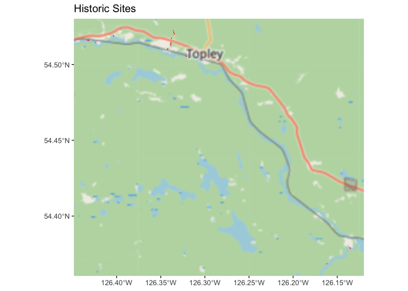

```r
ggplot(data = sites_joined_raw) +
  annotation_map_tile() +
  geom_sf(color = "red", fill = "red", size = 10) + # Plot the geometries
  # theme_minimal() + # Use a minimal theme for a cleaner look
  labs(title = "Historic Sites")
```

Looks like the following actions could happen:

1. having a look at the names of the sites so far there are a few things to consider.
   1. The contain abbreviations for `River` and `Creek` which in the long run are going to be duplicated over and over - so perhaps better excluded. Thinking we could just use the first name of the stream (ex. richfield_001) and then if we have “tributary to Maxam” or something like that in the long run we use “maxam_trib001_001” or something that will describe the trib with unique identifier.
   2. The year has been included in the site name but there are multiple years of work for the same sites so perhaps we ditch that as well and just use a cross-reference table to keep track of the years.
   3. We have two polygons with the same site name proposed (RC2-2021). Perhaps we just start over with site names and have unique names for each site. We can consider useing what we have already as far as numbers (ie. RC1, RC2 but make each site name a bit more descriptive, remove the year and have a unique ID for each polygon put together by Adam - ex. richfield_001, richfield_002, etc.)

To prepare for the next steps we will add the stream name to sites that don’t have it and break the proposed site names up so that we can use the numbering provided if we want to.

```r
sites_prep <- sites_joined_raw %>%
  # lets populate the stream name for everything. AlSERNBC and MWMT sites were on Richfield Creek
  dplyr::mutate(waterbody = case_when(
    fndr %in% c("SERNBC", "MWMT") ~ "Richfield Creek",
    TRUE ~ waterbody)) %>%
  # seperate the year from the site_name_proposed and the number from the abbreviated stream name
  tidyr::extract(site_name_proposed,
                 into = c("site_name_proposed_stream_name_abb", "site_name_proposed_number", "site_name_proposed_year"),
                 regex = "([A-Za-z]+)(\\d+)?-?(\\d+)?",
                 remove = FALSE)  %>%
  # add a column that flags if this is going to be a new prescribed polygon
  dplyr::mutate(prescribed = "no")
```

3. The fencing sites financed by SERN in 2021 and 2022 are not yet represented so those will need to be added to this collection. Because fencelines are lines and not polygons we will keep them as a seperate layer in the same geopackage.

Spatial representations of fencelines were provided by Adam following the contracts completed through SERN funding so we will add the spatial files provided to onedrive - interact with them programatically from here - and add them to the shared QGIS folder once processed (ie. two years of data amalgamated into one spatial file)…

```r
# read in the two fenceline files
fence_2021 <- sf::st_read(
  dsn = "~/Library/CloudStorage/OneDrive-Personal/Projects/2024-069-ow-wedzin-kwa-restoration/data/historic_site_info/richfield_2021_2022/New Fenceline.shp", quiet = TRUE) %>%
  janitor::clean_names() %>%
  # grab just the "New Fenceline" values from the nfl column
  dplyr::filter(nfl == "New Fenceline") %>%
  # add columns for type, fndr, waterbody, trt_year and comments
  dplyr::mutate(type = "fenceline",
                fndr = "SERNBC",
                waterbody = "Richfield Creek",
                trt_year = 2021,
                comments = "Fenceline installed on west side of Richfield Creek.") %>%
  # remove the nfl column
  dplyr::select(-nfl) %>%
  # we have multiple geometry types (linestring and multilinestring so we will convert to multilinestring before
  # combining)
  sf::st_cast("MULTILINESTRING") %>%
  # add a column that flags if this is going to be a new prescribed polygon
  dplyr::mutate(prescribed = "no")


fence_2022 <- sf::st_read(
  dsn = "~/Library/CloudStorage/OneDrive-Personal/Projects/2024-069-ow-wedzin-kwa-restoration/data/historic_site_info/richfield_2021_2022/RichfieldRestoration2022.gpkg", quiet = TRUE) %>%
  janitor::clean_names() %>%
  # add columns for type, fndr, waterbody, trt_year and comments
  dplyr::mutate(type = "fenceline",
                fndr = "SERNBC",
                waterbody = "Richfield Creek",
                trt_year = 2022,
                comments = "Fenceline installed on east side of Richfield Creek.") %>%
  # rename geom to geometry to match other files
  dplyr::rename(geometry = geom) %>%
  #remove the id col
  dplyr::select(-id) %>%
  # add a column that flags if this is going to be a new prescribed polygon
  dplyr::mutate(prescribed = "no")

# combine the two files and view
fence <- dplyr::bind_rows(fence_2022, fence_2021)
```

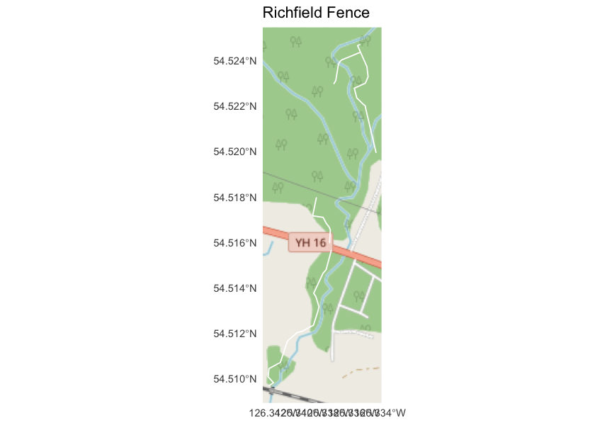

```r
ggplot(data = fence) +
  annotation_map_tile() +
  geom_sf() + # Plot the geometries
  theme_minimal() + # Use a minimal theme for a cleaner look
  labs(title = "Richfield Fence")
```

Now we will burn both the sites and the fencelines to a geopackage to share with the QGIS project. The best way to assign names to sites may be to do it manually in QGIS so we will burn out our finished product directly to the QGIS project directory. We turn this chunk off so that we only do it once vs every time we produce this memo.

```r
# write to geopackage
sites_joined_raw %>%
  # remove the fid
  select(-fid) %>%
  sf::st_write(dsn = "~/Projects/gis/restoration_wedzin_kwa/sites_restoration.gpkg",
               layer = "sites_poly",
               delete_layer = TRUE,
               quite = TRUE)


sf::st_write(fence,
             dsn = "~/Projects/gis/restoration_wedzin_kwa/sites_restoration.gpkg",
             layer = "sites_lines",
             delete_layer = TRUE,
             quite = TRUE)
```

**Still to do** 4. There is landowner information in an excel file that can be linked to these sites.

We can burn these files into a temporary location to view in google earth to see what is happening and do sanity checks too. We turn this chunk off so that we only do it once vs every time we produce this memo.

```r
# burn to kml to view in google earth
sites_poly %>%
  sf::st_write(
    dsn = "../temp/TreatmentSitesMaster.kml",
    delete_layer = TRUE)

sites_info %>%
  sf::st_write(
    dsn = "../temp/UB_Restoration_Site_Names.kml",
    delete_layer = TRUE)

sites_prep %>%
  sf::st_write(
    dsn = "../temp/historic_sites_joined.kml",
    delete_layer = TRUE)

fence %>%
  sf::st_write(
    dsn = "../temp/fencelines.kml",
    delete_layer = TRUE)
```

In order to render this memo we need a work around from the standard bookdown method. We run this command below by hand in the console to render the document to a new directory called `memos`.

```r
rmarkdown::render("scripts/historic_site_tidy.Rmd", output_file = "historic_site_tidy.html", output_dir = "memos")
```